[figure not shown]

# Project 2: Analyzing Chipotle Data

*Author: Joseph Nelson (DC)*

For Project 2, you will complete a series of exercises exploring [order data from Chipotle](https://github.com/TheUpshot/chipotle), compliments of *The New York Times'* "The Upshot."

For these exercises, you will conduct basic exploratory data analysis (Pandas not required) to understand the essentials of Chipotle's order data: how many orders are being made, the average price per order, how many different ingredients are used, etc. These allow you to practice business analysis skills while also becoming comfortable with Python.

## Basic Level

### Part 1: Read in the file with `csv.reader()` and store it in an object called `file_nested_list`.

Hint: This is a TSV (tab-separated value) file, and `csv.reader()` needs to be told [how to handle it](https://docs.python.org/2/library/csv.html).

```python
import csv
import pandas as pd
import numpy as np

from collections import namedtuple   # Convenient to store the data rows

DATA_FILE = './data/chipotle.tsv'
```

```python
# pandas import
# df = pd.read_csv(file_path, sep='\t', header=0)


# python csv import
file_nested_list = []

with open(DATA_FILE, 'rU') as f:
    rows = csv.reader(f, delimiter = '\t')

    for row in rows:
        file_nested_list.append(row)

f.close()
```

### Part 2: Separate `file_nested_list` into the `header` and the `data`.

```python
header = file_nested_list[0]
data = file_nested_list[1:]
```

```python
df = pd.DataFrame(data)
df.columns = header
```

```python
df.head()
# df.dtypes
```

|  | order_id | quantity | item_name | choice_description | item_price |
| --- | --- | --- | --- | --- | --- |
| 0 | 1 | 1 | Chips and Fresh Tomato Salsa | NULL | $2.39 |
| 1 | 1 | 1 | Izze | [Clementine] | $3.39 |
| 2 | 1 | 1 | Nantucket Nectar | [Apple] | $3.39 |
| 3 | 1 | 1 | Chips and Tomatillo-Green Chili Salsa | NULL | $2.39 |
| 4 | 2 | 2 | Chicken Bowl | [Tomatillo-Red Chili Salsa (Hot), [Black Beans... | $16.98 |

## Intermediate Level

### Part 3: Calculate the average price of an order.

Hint: Examine the data to see if the `quantity` column is relevant to this calculation.

Hint: Think carefully about the simplest way to do this!

```python
# Clean Item Price Series
# becasue "quantity" is an object/string data type - convert the series to integers


# remove dollar sign from item_price and convert to float
df['item_price'] = df.item_price.apply(lambda x: x.replace("$", ""))
df['item_price'] = df.item_price.apply(lambda x: float(x))


# Clean Quantity Series
df['quantity'] = df.quantity.apply(lambda x: int(x))


# Clean Order ID Series
df['order_id'] = df.order_id.apply(lambda x: int(x))
```

```python
# to account for the quantity of a given order - create a new column which takes the product of quantity and price

df['quantity*price'] = df.quantity * df.item_price
```

```python
# grouping by order id and sum by order id
order_sum_stat = df.groupby('order_id').sum().mean()
avg_order_total = order_sum_stat[2]




print(f'Using pandas: \n On average, each order totals: ${round(avg_order_total, 2)}\n')

# Using a for loop itterate over the dataframe
# to find each sum for each order id, appending each order total to an intermediate list

curr_id = 1
curr_tot = 0
result = []

for i in range(len(df.order_id)):

    if curr_id == df.iloc[i,0]:
        curr_tot += df.iloc[i,4] * df.iloc[i,1]
    else:
        result.append(round(curr_tot, 2))
        curr_tot = df.iloc[i,4] * df.iloc[i,1]
        curr_id += 1

result.append(round(curr_tot,2))



mean_order_total = 0
tot = 0
count = 0
for i in result:
    tot += i
    count += 1
    mean_order_total = tot/count



print(f"Using a for loop: \n On average, each order totals: ${round(mean_order_total, 2)} \n")

print(f"Using NumPy: \n On average, each order totals: ${round(np.mean(result), 2)}\n")
```

```
Using pandas:
 On average, each order totals: $21.39

Using a for loop:
 On average, each order totals: $21.39

Using NumPy:
 On average, each order totals: $21.39
```

### Part 4: Create a list (or set) named `unique_sodas` containing all of unique sodas and soft drinks that Chipotle sells.

Note: Just look for `'Canned Soda'` and `'Canned Soft Drink'`, and ignore other drinks like `'Izze'`.

```python
# replace coca cola with coke since there are more orders that take the description of coke and because they are the same
df['choice_description'] = df['choice_description'].apply(lambda x: x.replace('Coca Cola', 'Coke'))
```

```python
# define mask for item names that match the criteria for sodas or soft drinks
soda_mask = df['item_name'].str.contains('Canned')
```

```python
# assign unique list of canned soda or soft drinks to a numpy array
soda_array = df[soda_mask]['choice_description'].unique()
```

```python
# define empty list UNIQUE SODAS
unique_sodas = []

for i in soda_array:
    soda = i.replace("[", "").replace(']', "")

    if soda not in unique_sodas:
        unique_sodas.append(soda)


unique_sodas.sort()
print(f"The alphabetically sorted list of unique sodas and softdrinks offered at Chipotle: \n {unique_sodas}")
```

```
The alphabetically sorted list of unique sodas and softdrinks offered at Chipotle:
 ['Coke', 'Diet Coke', 'Diet Dr. Pepper', 'Dr. Pepper', 'Lemonade', 'Mountain Dew', 'Nestea', 'Sprite']
```

```python
df[soda_mask].groupby('choice_description').sum()
```

| choice_description | order_id | quantity | item_price | quantity*price |
| --- | --- | --- | --- | --- |
| [Coke] | 122594 | 154 | 187.38 | 267.96 |
| [Diet Coke] | 98916 | 134 | 164.46 | 233.18 |
| [Diet Dr. Pepper] | 10405 | 14 | 15.26 | 17.44 |
| [Dr. Pepper] | 13223 | 21 | 22.89 | 29.43 |
| [Lemonade] | 28836 | 34 | 42.50 | 52.50 |
| [Mountain Dew] | 8687 | 18 | 19.62 | 26.16 |
| [Nestea] | 21603 | 18 | 22.50 | 22.50 |
| [Sprite] | 76885 | 84 | 101.48 | 146.42 |

## Advanced Level

### Part 5: Calculate the average number of toppings per burrito.

Note: Let's ignore the `quantity` column to simplify this task.

Hint: Think carefully about the easiest way to count the number of toppings!

```python
# because the choice description values are type str, remove the brackets to clean the data in each cell

df['choice_description'] = df.choice_description.apply(lambda x: x.replace("[", "").replace("]", ""))
```

```python
# create mask to filter dataFrame by burrito

all_burrito_mask = df['item_name'].str.contains('Burrito')
```

```python
result = []
for i in df[all_burrito_mask]['choice_description']:
    count = 1
    for j in i:
        if j == ",":
            count += 1
    result.append(count)

avg_topping_count = np.mean(result)

print(f"Using for loops, \nAnd counting the number of commas as a proxy for the numebr of toppings, \nthe mean value of topping per order is: {round(avg_topping_count)}")






# the following assigns the list "result" to a copy of the dataframe as a column
burrito_df = df[all_burrito_mask].assign(topping_count = result)

print(f"\n\nUsing pandas Assign function to assign the list created in the loops to a dataFrame, \nThe average number of toppings per burrito is: {round(burrito_df['topping_count'].mean())}")
```

```
Using for loops,
And counting the number of commas as a proxy for the numebr of toppings,
the mean value of topping per order is: 5.0


Using pandas Assign function to assign the list created in the loops to a dataFrame,
The average number of toppings per burrito is: 5.0
```

### Part 6: Create a dictionary. Let the keys represent chip orders and the values represent the total number of orders.

Expected output: `{'Chips and Roasted Chili-Corn Salsa': 18, ... }`

Note: Please take the `quantity` column into account!

Optional: Learn how to use `.defaultdict()` to simplify your code.

```python
# remove hyphens from strings to get a more accurate count of item_names
df['item_name'] = df['item_name'].apply(lambda x: x.replace("-", " "))
```

```python
# create mask of for data containing chips in item names
mask_chips = df['item_name'].str.contains('Chips')

# create series of masked chip dataframe
chip_series = df[mask_chips].item_name
```

```python
# create dicitionary
chips_dict = {}


# itterate over set of unique chip orders
for i in chip_series.unique():
    count = 0

# nested itteration of all chip item_named series and check if
    for j in range(len(chip_series)):
        if i == df[mask_chips].iloc[j, 2]:
            count += df[mask_chips].iloc[j, 1]


# define chip dictionary key and value
    chips_dict[i] = count

print(f" \n\n Using for loops to itterate over the series of chips the following dictionary results:")

chips_dict
```

```
 Using for loops to itterate over the series of chips the following dictionary results:
```

```
{'Chips and Fresh Tomato Salsa': 130,
 'Chips and Tomatillo Green Chili Salsa': 78,
 'Side of Chips': 110,
 'Chips and Guacamole': 506,
 'Chips': 230,
 'Chips and Tomatillo Red Chili Salsa': 75,
 'Chips and Roasted Chili Corn Salsa': 41,
 'Chips and Mild Fresh Tomato Salsa': 1}
```

```python
# using groupyby method, finding the sum of item names and the to_dict method
print("\n\n Using multiple pandas methods, a more efficient process, creates the following dictionary:")

df[mask_chips].groupby("item_name").sum()['quantity'].to_dict()
```

```
 Using multiple pandas methods, a more efficient process, creates the following dictionary:
```

```
{'Chips': 230,
 'Chips and Fresh Tomato Salsa': 130,
 'Chips and Guacamole': 506,
 'Chips and Mild Fresh Tomato Salsa': 1,
 'Chips and Roasted Chili Corn Salsa': 41,
 'Chips and Tomatillo Green Chili Salsa': 78,
 'Chips and Tomatillo Red Chili Salsa': 75,
 'Side of Chips': 110}
```

## Bonus: Craft a problem statement about this data that interests you, and then answer it!

```python
# burrito_df.head(10)
# is there a significant correlation between the type of burrito and the number of toppings a customer orders?
```

```python
# d = {'Steak Burrito': True}
# burrito_df['is_steak'] = burrito_df['item_name'].map(d)
burrito_df['is_steak'] = burrito_df.item_name.apply(lambda x: 1 if x == 'Steak Burrito' else 0)
```

```python
# d = {'Chicken Burrito': True}
# burrito_df['is_Chicken'] = burrito_df['item_name'].map(d)
burrito_df['is_Chicken'] = burrito_df.item_name.apply(lambda x: 1 if x == "Chicken Burrito" else 0)

# d = {'Barbacoa Burrito': True}
# burrito_df['is_Barbacoa'] = burrito_df['item_name'].map(d)
burrito_df['is_Barbacoa'] = burrito_df.item_name.apply(lambda x: 1 if x == "Barbacoa Burrito" else 0)

# d = {'Veggie Burrito': True}
# burrito_df['is_Veggie'] = burrito_df['item_name'].map(d)
burrito_df['is_Veggie'] = burrito_df.item_name.apply(lambda x: 1 if x == "Veggie Burrito" else 0)
```

```python
burrito_df
```

|  | order_id | quantity | item_name | choice_description | item_price | quantity*price | topping_count | is_steak | is_Chicken | is_Barbacoa | is_Veggie |
| --- | --- | --- | --- | --- | --- | --- | --- | --- | --- | --- | --- |
| 7 | 4 | 1 | Steak Burrito | Tomatillo Red Chili Salsa, Fajita Vegetables, ... | 11.75 | 11.75 | 8 | 1 | 0 | 0 | 0 |
| 9 | 5 | 1 | Steak Burrito | Fresh Tomato Salsa, Rice, Black Beans, Pinto B... | 9.25 | 9.25 | 7 | 1 | 0 | 0 | 0 |
| 16 | 8 | 1 | Chicken Burrito | Tomatillo-Green Chili Salsa (Medium), Pinto Be... | 8.49 | 8.49 | 4 | 0 | 1 | 0 | 0 |
| 17 | 9 | 1 | Chicken Burrito | Fresh Tomato Salsa (Mild), Black Beans, Rice, ... | 8.49 | 8.49 | 6 | 0 | 1 | 0 | 0 |
| 21 | 11 | 1 | Barbacoa Burrito | Fresh Tomato Salsa (Mild), Tomatillo-Green Chi... | 8.99 | 8.99 | 7 | 0 | 0 | 1 | 0 |
| 23 | 12 | 1 | Chicken Burrito | Tomatillo-Green Chili Salsa (Medium), Tomatill... | 10.98 | 10.98 | 8 | 0 | 1 | 0 | 0 |
| 27 | 14 | 1 | Carnitas Burrito | Tomatillo-Green Chili Salsa (Medium), Roasted ... | 8.99 | 8.99 | 6 | 0 | 0 | 0 | 0 |
| 29 | 15 | 1 | Chicken Burrito | Tomatillo-Green Chili Salsa (Medium), Pinto Be... | 8.49 | 8.49 | 5 | 0 | 1 | 0 | 0 |
| 31 | 16 | 1 | Steak Burrito | Roasted Chili Corn Salsa (Medium), Fresh Tomat... | 8.99 | 8.99 | 5 | 1 | 0 | 0 | 0 |
| 43 | 20 | 1 | Steak Burrito | Fresh Tomato Salsa, Rice, Pinto Beans, Cheese,... | 11.75 | 11.75 | 7 | 1 | 0 | 0 | 0 |
| 45 | 21 | 1 | Chicken Burrito | Tomatillo-Red Chili Salsa (Hot), Black Beans, ... | 10.98 | 10.98 | 7 | 0 | 1 | 0 | 0 |
| 46 | 21 | 1 | Steak Burrito | Tomatillo-Red Chili Salsa (Hot), Rice, Fajita ... | 8.99 | 8.99 | 4 | 1 | 0 | 0 | 0 |
| 48 | 22 | 1 | Steak Burrito | Fresh Tomato Salsa (Mild), Roasted Chili Corn ... | 8.99 | 8.99 | 6 | 1 | 0 | 0 | 0 |
| 50 | 23 | 1 | Steak Burrito | Roasted Chili Corn Salsa (Medium), Rice, Fajit... | 8.99 | 8.99 | 6 | 1 | 0 | 0 | 0 |
| 52 | 24 | 1 | Chicken Burrito | Roasted Chili Corn Salsa (Medium), Black Beans... | 10.98 | 10.98 | 8 | 0 | 1 | 0 | 0 |
| 57 | 26 | 1 | Veggie Burrito | Tomatillo Red Chili Salsa, Fajita Vegetables, ... | 11.25 | 11.25 | 8 | 0 | 0 | 0 | 1 |
| 63 | 28 | 1 | Chicken Burrito | Fresh Tomato Salsa, Rice, Black Beans, Cheese | 8.75 | 8.75 | 4 | 0 | 1 | 0 | 0 |
| 64 | 29 | 1 | Steak Burrito | Tomatillo-Red Chili Salsa (Hot), Black Beans, ... | 8.99 | 8.99 | 7 | 1 | 0 | 0 | 0 |
| 67 | 30 | 1 | Steak Burrito | Tomatillo-Red Chili Salsa (Hot), Rice, Cheese | 8.99 | 8.99 | 3 | 1 | 0 | 0 | 0 |
| 68 | 30 | 1 | Chicken Burrito | Tomatillo-Red Chili Salsa (Hot), Black Beans, ... | 10.98 | 10.98 | 7 | 0 | 1 | 0 | 0 |
| 69 | 31 | 1 | Steak Burrito | Roasted Chili Corn Salsa (Medium), Rice, Black... | 8.99 | 8.99 | 4 | 1 | 0 | 0 | 0 |
| 71 | 32 | 1 | Steak Burrito | Tomatillo-Red Chili Salsa (Hot), Black Beans, ... | 8.99 | 8.99 | 6 | 1 | 0 | 0 | 0 |
| 73 | 33 | 1 | Chicken Burrito | Tomatillo Red Chili Salsa, Rice, Black Beans, ... | 8.75 | 8.75 | 5 | 0 | 1 | 0 | 0 |
| 81 | 36 | 1 | Barbacoa Burrito | Fresh Tomato Salsa, Rice, Pinto Beans, Cheese,... | 9.25 | 9.25 | 6 | 0 | 0 | 1 | 0 |
| 82 | 36 | 1 | Chicken Burrito | Fresh Tomato Salsa, Rice, Black Beans, Cheese,... | 8.75 | 8.75 | 6 | 0 | 1 | 0 | 0 |
| 83 | 37 | 1 | Chicken Burrito | Tomatillo Green Chili Salsa, Rice, Black Beans... | 8.75 | 8.75 | 5 | 0 | 1 | 0 | 0 |
| 88 | 39 | 1 | Carnitas Burrito | Fresh Tomato Salsa, Rice, Pinto Beans, Sour Cr... | 9.25 | 9.25 | 5 | 0 | 0 | 0 | 0 |
| 93 | 41 | 1 | Carnitas Burrito | Roasted Chili Corn Salsa, Sour Cream, Guacamole | 11.75 | 11.75 | 3 | 0 | 0 | 0 | 0 |
| 98 | 43 | 1 | Chicken Burrito | Tomatillo Red Chili Salsa, Rice, Black Beans, ... | 8.75 | 8.75 | 4 | 0 | 1 | 0 | 0 |
| 101 | 45 | 1 | Steak Burrito | Tomatillo-Green Chili Salsa (Medium), Rice, Ch... | 8.99 | 8.99 | 5 | 1 | 0 | 0 | 0 |
| ... | ... | ... | ... | ... | ... | ... | ... | ... | ... | ... | ... |
| 4473 | 1783 | 1 | Steak Burrito | Tomatillo Green Chili Salsa, Rice, Fajita Vege... | 9.25 | 9.25 | 6 | 1 | 0 | 0 | 0 |
| 4478 | 1785 | 1 | Chicken Burrito | Fresh Tomato Salsa, Fajita Vegetables, Rice | 8.75 | 8.75 | 3 | 0 | 1 | 0 | 0 |
| 4482 | 1786 | 1 | Carnitas Burrito | Fresh Tomato Salsa, Fajita Vegetables, Rice, P... | 11.75 | 11.75 | 8 | 0 | 0 | 0 | 0 |
| 4487 | 1786 | 1 | Carnitas Burrito | Fresh Tomato Salsa, Rice, Black Beans, Guacamo... | 11.75 | 11.75 | 5 | 0 | 0 | 0 | 0 |
| 4492 | 1787 | 1 | Chicken Burrito | Tomatillo Green Chili Salsa, Rice, Black Beans... | 8.75 | 8.75 | 6 | 0 | 1 | 0 | 0 |
| 4508 | 1793 | 1 | Steak Burrito | Brown Rice | 8.99 | 8.99 | 1 | 1 | 0 | 0 | 0 |
| 4519 | 1797 | 1 | Veggie Burrito | Fresh Tomato Salsa, Rice, Pinto Beans, Cheese | 8.75 | 8.75 | 4 | 0 | 0 | 0 | 1 |
| 4521 | 1798 | 1 | Chicken Burrito | Roasted Chili Corn Salsa, Guacamole, Lettuce, ... | 11.25 | 11.25 | 6 | 0 | 1 | 0 | 0 |
| 4524 | 1799 | 1 | Chicken Burrito | Roasted Chili Corn Salsa, Rice, Black Beans, C... | 8.75 | 8.75 | 4 | 0 | 1 | 0 | 0 |
| 4528 | 1800 | 1 | Chicken Burrito | Fresh Tomato Salsa, Rice, Black Beans, Sour Cr... | 8.75 | 8.75 | 6 | 0 | 1 | 0 | 0 |
| 4530 | 1801 | 1 | Chicken Burrito | Roasted Chili Corn Salsa, Fajita Vegetables, R... | 8.75 | 8.75 | 5 | 0 | 1 | 0 | 0 |
| 4533 | 1802 | 1 | Chicken Burrito | Tomatillo Red Chili Salsa, Fajita Vegetables, ... | 11.25 | 11.25 | 8 | 0 | 1 | 0 | 0 |
| 4536 | 1803 | 1 | Steak Burrito | Fresh Tomato Salsa, Fajita Vegetables, Rice, C... | 9.25 | 9.25 | 4 | 1 | 0 | 0 | 0 |
| 4543 | 1806 | 1 | Chicken Burrito | Fresh Tomato Salsa, Fajita Vegetables, Rice | 8.75 | 8.75 | 3 | 0 | 1 | 0 | 0 |
| 4546 | 1807 | 1 | Steak Burrito | Fresh Tomato Salsa, Rice, Black Beans, Cheese | 9.25 | 9.25 | 4 | 1 | 0 | 0 | 0 |
| 4556 | 1811 | 1 | Chicken Burrito | Tomatillo Green Chili Salsa, Fajita Vegetables... | 11.25 | 11.25 | 8 | 0 | 1 | 0 | 0 |
| 4558 | 1812 | 1 | Chicken Burrito | Fresh Tomato Salsa, Rice, Black Beans, Cheese,... | 8.75 | 8.75 | 6 | 0 | 1 | 0 | 0 |
| 4559 | 1812 | 1 | Chicken Burrito | Tomatillo Red Chili Salsa, Rice, Cheese, Guaca... | 11.25 | 11.25 | 5 | 0 | 1 | 0 | 0 |
| 4566 | 1816 | 1 | Chicken Burrito | Roasted Chili Corn Salsa, Pinto Beans, Cheese,... | 8.75 | 8.75 | 4 | 0 | 1 | 0 | 0 |
| 4569 | 1817 | 1 | Chicken Burrito | Fresh Tomato Salsa, Fajita Vegetables, Rice | 8.75 | 8.75 | 3 | 0 | 1 | 0 | 0 |
| 4578 | 1821 | 1 | Carnitas Burrito | Tomatillo Green Chili Salsa, Rice, Pinto Beans... | 9.25 | 9.25 | 4 | 0 | 0 | 0 | 0 |
| 4592 | 1825 | 1 | Barbacoa Burrito | Tomatillo Red Chili Salsa, Rice, Fajita Vegeta... | 11.75 | 11.75 | 7 | 0 | 0 | 1 | 0 |
| 4602 | 1827 | 1 | Barbacoa Burrito | Tomatillo Green Chili Salsa | 9.25 | 9.25 | 1 | 0 | 0 | 1 | 0 |
| 4603 | 1827 | 1 | Barbacoa Burrito | Tomatillo Green Chili Salsa | 9.25 | 9.25 | 1 | 0 | 0 | 1 | 0 |
| 4607 | 1829 | 1 | Steak Burrito | Tomatillo Green Chili Salsa, Rice, Cheese, Sou... | 11.75 | 11.75 | 5 | 1 | 0 | 0 | 0 |
| 4608 | 1829 | 1 | Veggie Burrito | Tomatillo Red Chili Salsa, Fajita Vegetables, ... | 11.25 | 11.25 | 7 | 0 | 0 | 0 | 1 |
| 4610 | 1830 | 1 | Steak Burrito | Fresh Tomato Salsa, Rice, Sour Cream, Cheese, ... | 11.75 | 11.75 | 6 | 1 | 0 | 0 | 0 |
| 4611 | 1830 | 1 | Veggie Burrito | Tomatillo Green Chili Salsa, Rice, Fajita Vege... | 11.25 | 11.25 | 5 | 0 | 0 | 0 | 1 |
| 4617 | 1833 | 1 | Steak Burrito | Fresh Tomato Salsa, Rice, Black Beans, Sour Cr... | 11.75 | 11.75 | 7 | 1 | 0 | 0 | 0 |
| 4618 | 1833 | 1 | Steak Burrito | Fresh Tomato Salsa, Rice, Sour Cream, Cheese, ... | 11.75 | 11.75 | 6 | 1 | 0 | 0 | 0 |

1172 rows × 11 columns

```python
print(f"If an order is a Steak Burrito there is not a significant correlation with topping count: \n {burrito_df['topping_count'].corr(burrito_df['is_steak'])}\n")
print(f"If an order is a Chicken Burrito there is not a significant coorelation with topping count \n {burrito_df['topping_count'].corr(burrito_df['is_Chicken'])}\n")
print(f"If an order is a Barbacoa Burrito there is not a significant coorelation with topping count \n {burrito_df['topping_count'].corr(burrito_df['is_Barbacoa'])}\n")
print(f"If an order is a Veggie Burrito there is a slightly positive correlation with topping count, indicating a slight increase in topping count given that the burrito is vegitarian \n {burrito_df['topping_count'].corr(burrito_df['is_Veggie'])}\n")
```

```
If an order is a Steak Burrito there is not a significant correlation with topping count:
 0.005823803896634852

If an order is a Chicken Burrito there is not a significant coorelation with topping count
 -0.042722419373010974

If an order is a Barbacoa Burrito there is not a significant coorelation with topping count
 -0.05015916758261818

If an order is a Veggie Burrito there is a slightly positive correlation with topping count, indicating a slight increase in topping count given that the burrito is vegitarian
 0.11459067324996862
```

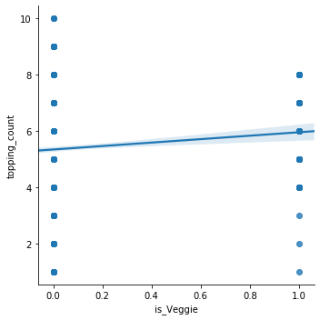

```python
import seaborn as sns
sns.lmplot(x='is_Veggie',y='topping_count',data=burrito_df,fit_reg=True);
```